# Decomposition of AML transcriptomes to predict treatment response

```r
library(hsc19)
library(Seurat)
library(ggplot2)
set.seed(1337)
```

## Data preparation

The inputs for the Renders dataset (ArrayExpress accession E-MTAB-14142) are included in `data_Venetoclax/`: the count matrix, the study sample annotations (`E-MTAB-14142.sdrf.txt`), and the supplementary scores (`Metadata_Lars_10022026.csv`). We use the original study annotations for both response outcomes and the supplementary table for the comparison scores. Only diagnostic LSC samples are retained. Sequencing lanes are deduplicated using the sample-level columns of the annotation table.

```r
study_metadata <- read.delim(
  "data_Venetoclax/E-MTAB-14142.sdrf.txt", check.names = FALSE,
  na.strings = c("", "NA")
)
study_metadata <- unique(study_metadata[, seq_len(10)])
study_metadata <- subset(
  study_metadata,
  `Characteristics[cell type]` == "LSC" &
    `Characteristics[disease staging]` == "Diagnosis"
)

scores <- read.csv(
  "data_Venetoclax/Metadata_Lars_10022026.csv", check.names = FALSE,
  na.strings = c("", "NA")
)
join_columns <- c(
  "Characteristics[individual]", "Comment[ENA_SAMPLE]", "Source Name",
  "Characteristics[cell type]", "Characteristics[disease staging]"
)
score_columns <- c("3GeneScore", "New Score", "Mode-AML", "ELN-2022",
                   "PDX", "MAC-Score_LSC")
meta <- merge(study_metadata, scores[, c(join_columns, score_columns)],
              by = join_columns)
names(meta)[match(score_columns, names(meta))] <-
  c("threegene", "newscore", "modeaml", "eln2022", "PDX", "MAC")
rownames(meta) <- with(meta, paste(
  `Characteristics[individual]`, `Characteristics[cell type]`,
  `Characteristics[disease staging]`, sep = "_"
))
stopifnot(!anyDuplicated(rownames(meta)))

counts <- read.csv(
  "data_Venetoclax/Count_matrix_LSC_MATURE.csv.gz", row.names = 1,
  check.names = FALSE
)
stopifnot(all(rownames(meta) %in% colnames(counts)))
counts <- as.matrix(counts[, rownames(meta), drop = FALSE])

s <- CreateSeuratObject(counts, meta.data = meta)
s <- NormalizeData(s, verbose = FALSE)
s <- FindVariableFeatures(s, verbose = FALSE)
s <- ScaleData(s, verbose = FALSE)
meta <- meta[colnames(s), , drop = FALSE]

meta$response_vv <- meta$`Characteristics[response_vv]` == "responder"
meta$response_da <- meta$`Characteristics[response_da]` == "responder"
meta$threegene <- factor(meta$threegene, levels = c("Low", "Medium", "High"))
meta$newscore <- factor(meta$newscore, levels = c("Favorable", "Adverse"))
meta$threegene_num <- as.integer(meta$threegene)
meta$newscore_num <- as.integer(meta$newscore)
has.vv <- rownames(meta)[!is.na(meta$response_vv)]
has.da <- rownames(meta)[!is.na(meta$response_da)]
```

## Decompose data into GRPs

```r
result <- decompose(s = s)
```

```
#> Run on 122 samples. On the overlapping gene set of 748 genes, 19 programs explain 13.3 % of the gene expression variance in your data. For comparison, 19 principal components explain 74.6 %
```

```r
print(result)
```

```
#> Decomposition object of 122 samples (AML4_LSC_Diagnosis, AML5_LSC_Diagnosis, ...), run on 748 genes. 19 programs explain 13.3 % of the gene expression variance in your data. For comparison, 19 principal components explain 74.6 %
```

## Associate GRPs with treatment response

Each analysis includes all samples with a recorded outcome. Missing comparison scores are omitted only from the models requiring those scores, so GRP models can still use all outcome-annotated samples. The numeric scores encode their ordered risk categories. The custom models below treat the scores as categorical or continuous predictors according to their original type.

The association functions report Wilcoxon tests and compare out-of-fold ROC AUCs over ten repeated cross-validation runs. They use ten folds for more than 50 samples and leave-one-out cross-validation for smaller cohorts. The standard deviations describe variation across repeats, rather than confidence intervals. The calculations can take several minutes; reduce `cores` for machines with fewer available CPUs.

```r
models <- c("threegene", "eln2022", "newscore", "MAC")
names(models) <- c("3 Gene score", "ELN22 risk", "New Score", "MAC Score")
other_predictors <- c("threegene_num", "newscore_num")

grp2output_vv <- associate_binary_outcome(
  subset(result, include = has.vv), meta[has.vv, , drop = FALSE],
  "response_vv", other.predictors = other_predictors,
  run.ML = TRUE, replicates = 10, cores = 10, arbitrary.models = models
)
saveRDS(grp2output_vv, file = "grp2output_vv.rds")
# grp2output_da <- associate_binary_outcome(
#   subset(result, include = has.da), meta[has.da, , drop = FALSE],
#   "response_da", other.predictors = other_predictors,
#   run.ML = TRUE, replicates = 10, cores = 10
# )
```

```r
data.frame(
  outcome = c("VV", "DA"),
  samples = c(length(has.vv), length(has.da)),
  responders = c(sum(meta$response_vv, na.rm = TRUE),
                 sum(meta$response_da, na.rm = TRUE))
)
```

```
#>   outcome samples responders
#> 1      VV      91         66
#> 2      DA      45         22
```

```r
grp2output_vv$p.values
```

```
#>                   factor_id    p_outcome sign_outcome
#> Factor_1           Factor_1 2.283029e-01           -1
#> Factor_2           Factor_2 5.603202e-01            1
#> Factor_3           Factor_3 9.609982e-01           -1
#> Factor_4           Factor_4 4.789867e-02            1
#> Factor_5           Factor_5 4.418465e-01            1
#> Factor_6           Factor_6 5.314023e-03           -1
#> Factor_8           Factor_8 1.142208e-02           -1
#> Factor_9           Factor_9 5.205218e-02            1
#> Factor_11         Factor_11 8.623558e-01           -1
#> Factor_12         Factor_12 2.532444e-01           -1
#> Factor_13         Factor_13 7.522807e-01           -1
#> Factor_14         Factor_14 8.275603e-01            1
#> Factor_15         Factor_15 9.893592e-01           -1
#> Factor_16         Factor_16 4.686831e-01           -1
#> Factor_17         Factor_17 1.988756e-01            1
#> Factor_18         Factor_18 1.935833e-05            1
#> Factor_19         Factor_19 8.535524e-02           -1
#> Factor_20         Factor_20 8.903892e-01            1
#> Factor_21         Factor_21 3.347038e-01           -1
#> threegene_num threegene_num 8.089505e-02            1
#> newscore_num   newscore_num 6.010817e-04           -1
```

```r
# grp2output_da$p.values
```

## Response by score stratum

GRP18 is oriented using the package’s program annotation and divided into tertiles. MAC scores are likewise divided into tertiles among samples with observed VV response and MAC score. The bars show exact 90% binomial confidence intervals; point sizes indicate the number of samples in each stratum.

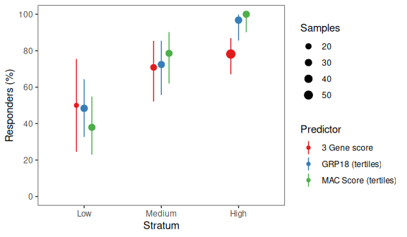

```r
plf <- meta[has.vv, , drop = FALSE]
grp18_sign <- factor_annotation$multiply_with[
  factor_annotation$factor_id == "Factor_18"
]
strata <- c("Low", "Medium", "High")
plf$GRP18 <- factor(
  infotheo::discretize(data.frame(score =
    result@result["Factor_18", has.vv] * grp18_sign), nbins = 3)[[1]],
  levels = 1:3, labels = strata
)
plf$MAC_tertile <- NA_integer_
with_mac <- !is.na(plf$MAC)
plf$MAC_tertile[with_mac] <- infotheo::discretize(
  data.frame(score = plf$MAC[with_mac]), nbins = 3
)[[1]]
plf$MAC_tertile <- factor(plf$MAC_tertile, levels = 1:3, labels = strata)

score_names <- c(GRP18 = "GRP18 (tertiles)", threegene = "3 Gene score",
                 MAC_tertile = "MAC Score (tertiles)")
response_summary <- do.call(rbind, lapply(names(score_names), function(score) {
  do.call(rbind, lapply(strata, function(stratum) {
    response <- plf$response_vv[!is.na(plf[[score]]) & plf[[score]] == stratum]
    if (!length(response)) return(NULL)
    ci <- binom.test(sum(response), length(response), conf.level = 0.9)$conf.int
    data.frame(score = score_names[[score]], stratum = stratum,
               n = length(response), response = mean(response),
               lower = ci[1], upper = ci[2])
  }))
}))
response_summary$stratum <- factor(response_summary$stratum, levels = strata)

ggplot(response_summary, aes(stratum, response, color = score)) +
  geom_linerange(aes(ymin = lower, ymax = upper),
                 position = position_dodge(width = 0.3)) +
  geom_point(aes(size = n), position = position_dodge(width = 0.3)) +
  scale_y_continuous("Responders (%)", breaks = seq(0, 1, 0.2),
                     labels = seq(0, 100, 20), limits = c(0, 1)) +
  scale_size_area(name = "Samples", max_size = 4) +
  scale_color_brewer(palette = "Set1", name = "Predictor") +
  xlab("Stratum") + theme_bw() + theme(panel.grid = element_blank())
```

## Compare predictive performance

The best single GRP is selected within each training fold; the LASSO GRP model combines the decomposed programs. The full-transcriptome upper bound is the best of the transcriptome-wide models (principal component regression, LASSO, and DE-based regression), as in the other vignettes. All displayed AUCs are based on held-out predictions. Models with missing scores may be evaluated on fewer samples.

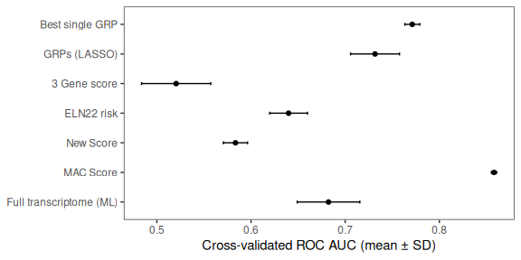

```r
model_labels <- c(
  AUC.best.factor = "Best single GRP", AUC.lasso.factors = "GRPs (LASSO)",
  "3 Gene score" = "3 Gene score", "ELN22 risk" = "ELN22 risk",
  "New Score" = "New Score", "MAC Score" = "MAC Score",
  "Full transcriptome (ML)" = "Full transcriptome (ML)"
)
ml_models <- c("AUC.logit.de", "AUC.lasso.de", "AUC.logit.pcr", "AUC.lasso.pcr")
performance <- data.frame(
  model = names(grp2output_vv$aucs), auc = grp2output_vv$aucs,
  sd = grp2output_vv$aucs.sd
)
best_ml <- subset(performance, model %in% ml_models)
best_ml <- best_ml[which.max(best_ml$auc), , drop = FALSE]
best_ml$model <- "Full transcriptome (ML)"
performance <- rbind(subset(performance, model %in% names(model_labels)), best_ml)
performance$model <- factor(performance$model, levels = rev(names(model_labels)))
ggplot(performance, aes(auc, model)) +
  geom_point() +
  geom_errorbar(aes(xmin = auc - sd, xmax = auc + sd),
                orientation = "y", width = 0.1) +
  scale_y_discrete(labels = model_labels) +
  xlab("Cross-validated ROC AUC (mean ± SD)") + ylab(NULL) +
  theme_bw() + theme(panel.grid = element_blank())
```

The corresponding auPRCs use average precision, with responders as the positive class, and summarize the same held-out predictions across CV replicates.

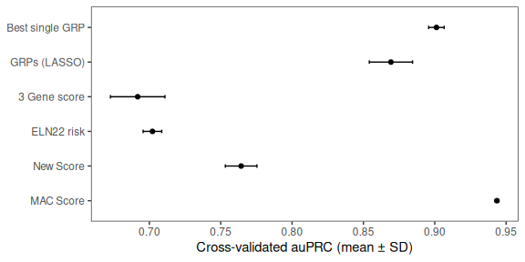

```r
pr_performance <- data.frame(
  model = names(grp2output_vv$auprcs), auprc = grp2output_vv$auprcs,
  sd = grp2output_vv$auprcs.sd
)
pr_performance <- subset(pr_performance, model %in% names(model_labels))
pr_performance$model <- factor(pr_performance$model, levels = rev(names(model_labels)))
ggplot(pr_performance, aes(auprc, model)) +
  geom_point() +
  geom_errorbar(aes(xmin = auprc - sd, xmax = auprc + sd),
                orientation = "y", width = 0.1) +
  scale_y_discrete(labels = model_labels) +
  xlab("Cross-validated auPRC (mean ± SD)") + ylab(NULL) +
  theme_bw() + theme(panel.grid = element_blank())
```